# Geospatial Assignment 2

Irache Vergara, Gretchen Moulton, Viktoria Gagua, Daniela Guggenberger

2025-02-04

## 1 Load libraries

```r
rm(list = ls())

# Library
library(readxl)
library(sf)
library(ggplot2)
library(maps)
library(dplyr)
library(tidyr)
library(readr)
library(rnaturalearth)
library(rnaturalearthdata)
library(osmdata)
library(remotes)
library(afrilearndata)
library(RColorBrewer)
library(gridExtra)
```

## 2 Load data

```r
# Define the base URL for raw shapefiles on GitHub
github_base <- "/vsicurl/https://raw.githubusercontent.com/Viktoriag27/Geospatial_Assignment_2/main/data"

# Define file paths for each dataset
pop <- st_read(paste0(github_base, "/ne_110m_populated_places/ne_110m_populated_places.shp"))
countries <- st_read(paste0(github_base, "/ne_110m_admin_0_countries/ne_110m_admin_0_countries.shp"))
airports <- st_read(paste0(github_base, "/ne_10m_airports/ne_10m_airports.shp"))
ports <- st_read(paste0(github_base, "/ne_10m_ports/ne_10m_ports.shp"))
locations <- st_read(paste0(github_base, "/ne_10m_populated_places/ne_10m_populated_places.shp"))
# Convert and transform spatial data if needed
countries <- st_as_sf(countries)
airports <- st_as_sf(airports)
airports <- st_transform(airports, crs = 4326)
ports <- st_as_sf(ports)
ports <- st_transform(ports, crs = 4326)
```

## 3 Graphs and Visuals

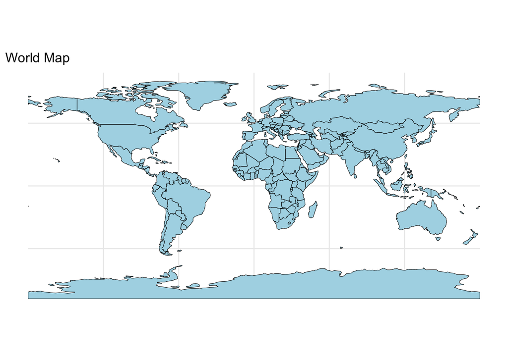

```r
# Plot the world map
ggplot(data = countries) +
  geom_sf(fill = "lightblue", color = "black") +  # Fill color and borders
  theme_minimal() +
  labs(title = "World Map")
```

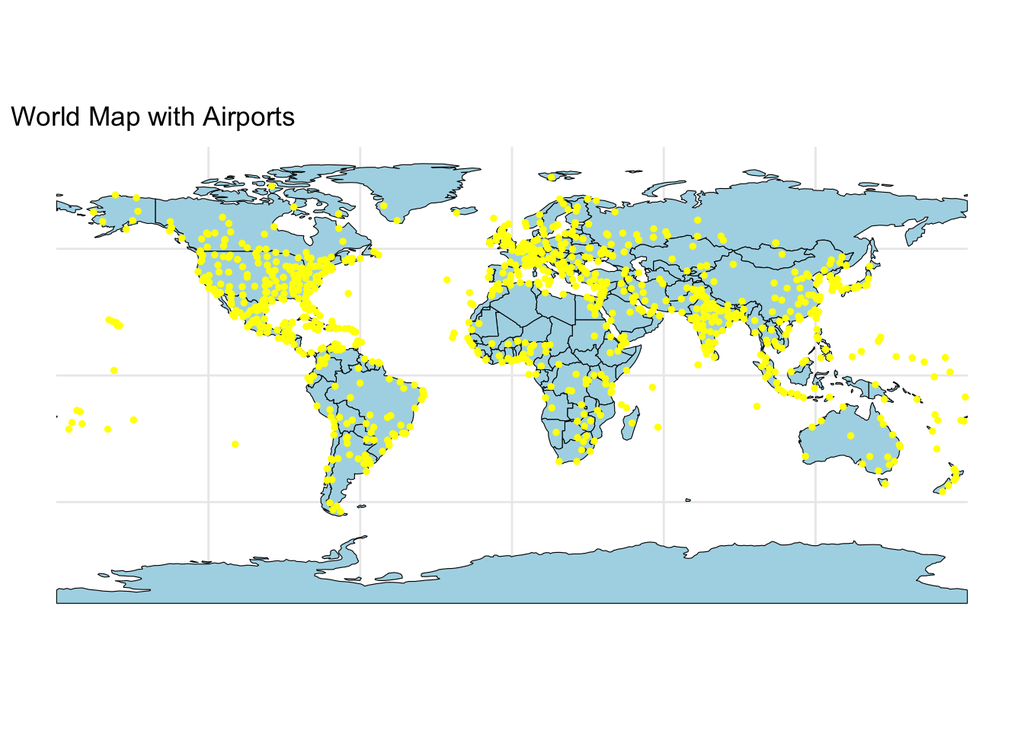

```r
#airports on map
ggplot() +
  # Plot world map
  geom_sf(data = countries, fill = "lightblue", color = "black") +
  # Plot airports on top
  geom_sf(data = airports, color = "yellow", size = 1) +
  theme_minimal() +
  labs(title = "World Map with Airports")
```

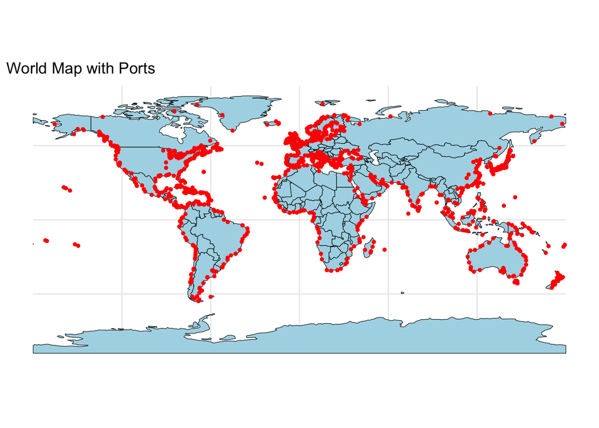

```r
#ports on map
ggplot() +
  # Plot world map
  geom_sf(data = countries, fill = "lightblue", color = "black") +
  # Plot airports on top
  geom_sf(data = ports, color = "red", size = 1) +
  theme_minimal() +
  labs(title = "World Map with Ports")
```

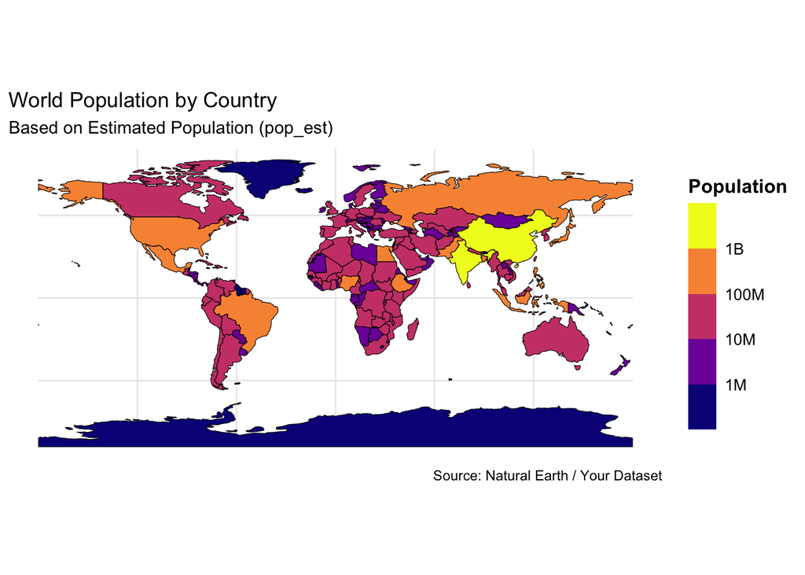

```r
ggplot(data = countries) +
  geom_sf(aes(fill = POP_EST), color = "black", size = 0.2) +  # Fill based on population
  scale_fill_viridis_b(option = "plasma", trans = "log", name = "Population",
                       breaks = c(1e6, 1e7, 1e8, 1e9),  # Define readable breaks
                       labels = c("1M", "10M", "100M", "1B")) +  # Format labels
  theme_minimal() +
  labs(title = "World Population by Country",
       subtitle = "Based on Estimated Population (pop_est)",
       caption = "Source: Natural Earth / Your Dataset") +
  theme(legend.position = "right",  # Move legend to the right side
        legend.text = element_text(size = 10),  # Increase text size
        legend.title = element_text(size = 12, face = "bold"),  # Bold legend title
        legend.key.height = unit(1, "cm"))
```

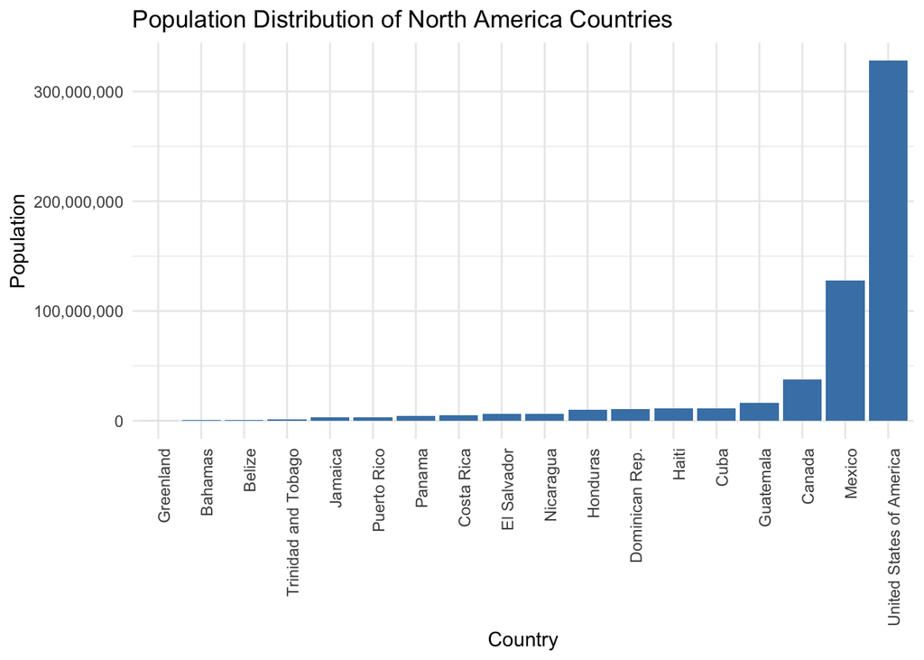

```r
plot_population_distribution <- function(continent_name) {
  continent_data <- countries %>% filter(CONTINENT == continent_name)

  ggplot(continent_data, aes(x = reorder(NAME, POP_EST), y = POP_EST)) +
    geom_bar(stat = "identity", fill = "steelblue") +  # Bar plot for population
    labs(title = paste("Population Distribution of", continent_name, "Countries"),
         x = "Country",
         y = "Population") +
    scale_y_continuous(labels = scales::comma) +  # Format y-axis with commas
    theme_minimal() +
    theme(axis.text.x = element_text(angle = 90, hjust = 1))
}

# List of continents
continents <- c("North America", "South America", "Asia", "Europe", "Africa")

# Apply the function to each continent and create the plots
plot_north_america <- plot_population_distribution("North America")
plot_south_america <- plot_population_distribution("South America")
plot_asia <- plot_population_distribution("Asia")
plot_europe <- plot_population_distribution("Europe")
plot_africa <- plot_population_distribution("Africa")

# Display each plot separately
print(plot_north_america)
```

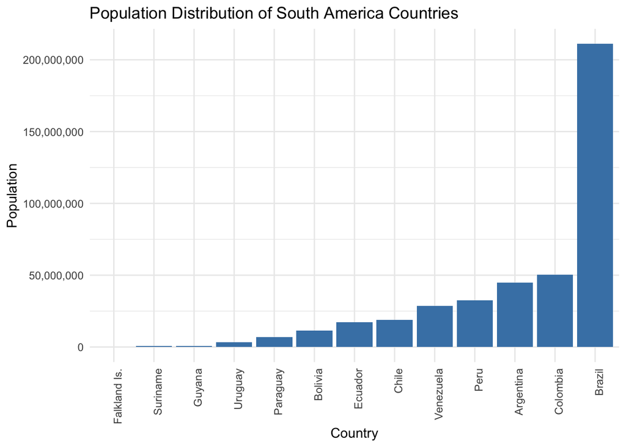

```r
print(plot_south_america)
```

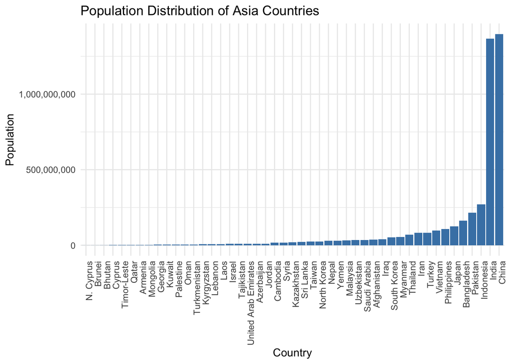

```r
print(plot_asia)
```

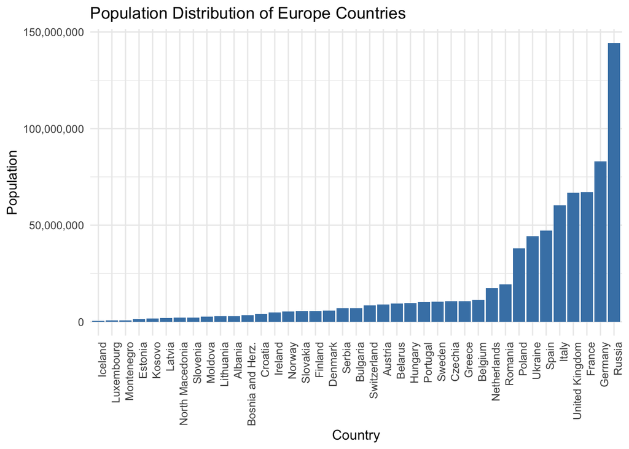

```r
print(plot_europe)
```

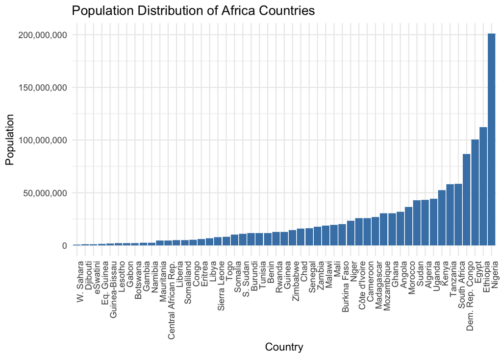

```r
print(plot_africa)
```

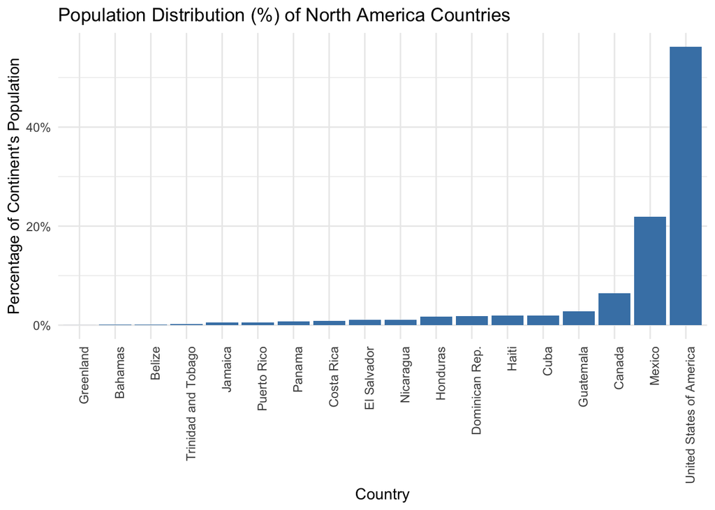

```r
plot_population_distribution <- function(continent_name) {
  continent_data <- countries %>%
    filter(CONTINENT == continent_name) %>%
    mutate(Pop_Percent = (POP_EST / sum(POP_EST, na.rm = TRUE)) * 100)  # Calculate % of total

  ggplot(continent_data, aes(x = reorder(NAME, Pop_Percent), y = Pop_Percent)) +
    geom_bar(stat = "identity", fill = "steelblue") +  # Bar plot for % population
    labs(title = paste("Population Distribution (%) of", continent_name, "Countries"),
         x = "Country",
         y = "Percentage of Continent's Population") +
    scale_y_continuous(labels = scales::percent_format(scale = 1)) +  # Format as percentages
    theme_minimal() +
    theme(axis.text.x = element_text(angle = 90, hjust = 1))
}

# List of continents
continents <- c("North America", "South America", "Asia", "Europe", "Africa")

# Apply the function to each continent and create the plots
plot_north_america <- plot_population_distribution("North America")
plot_south_america <- plot_population_distribution("South America")
plot_asia <- plot_population_distribution("Asia")
plot_europe <- plot_population_distribution("Europe")
plot_africa <- plot_population_distribution("Africa")

# Display each plot separately
print(plot_north_america)
```

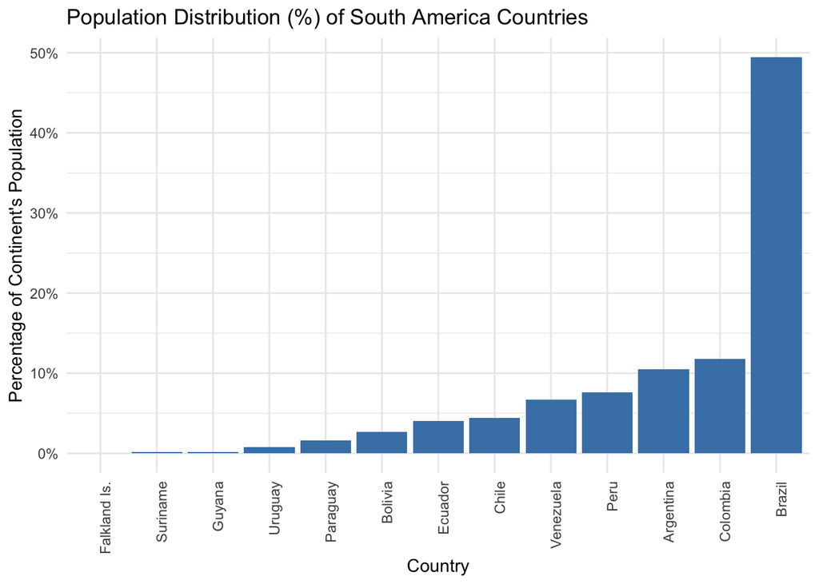

```r
print(plot_south_america)
```

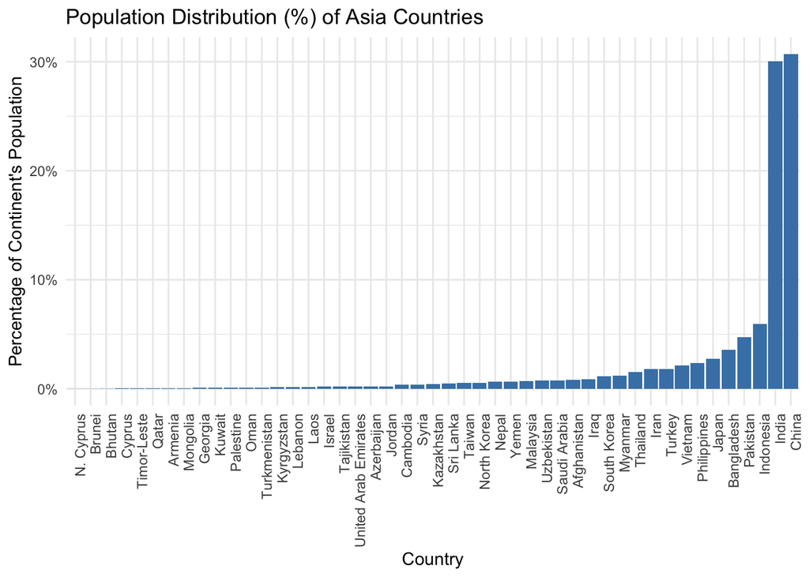

```r
print(plot_asia)
```

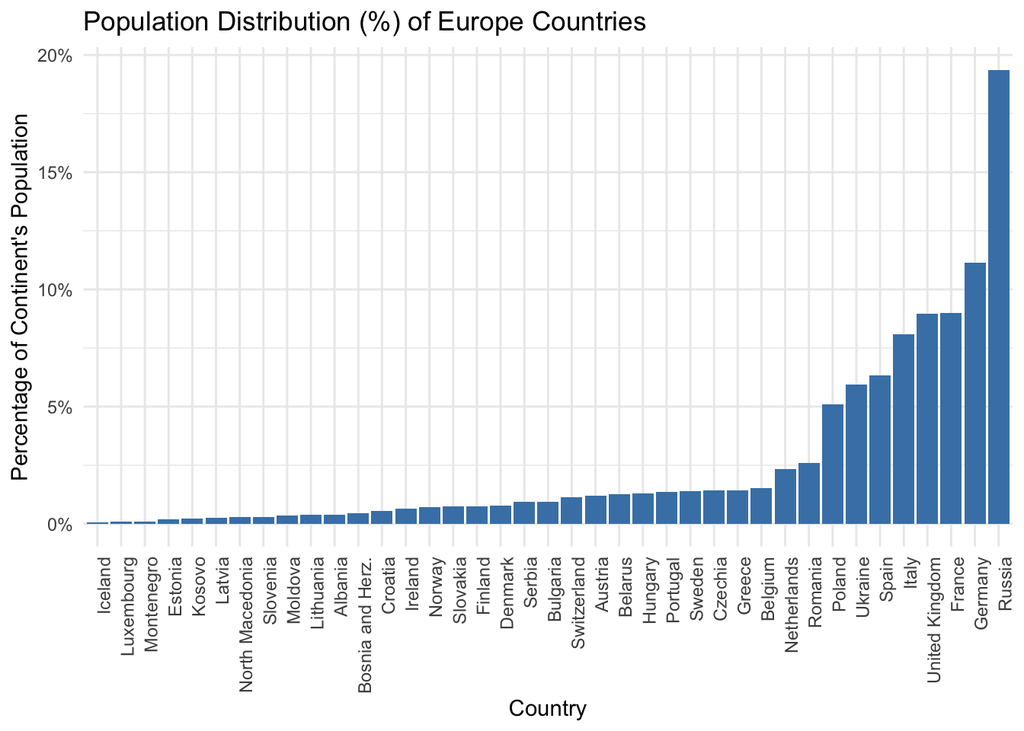

```r
print(plot_europe)
```

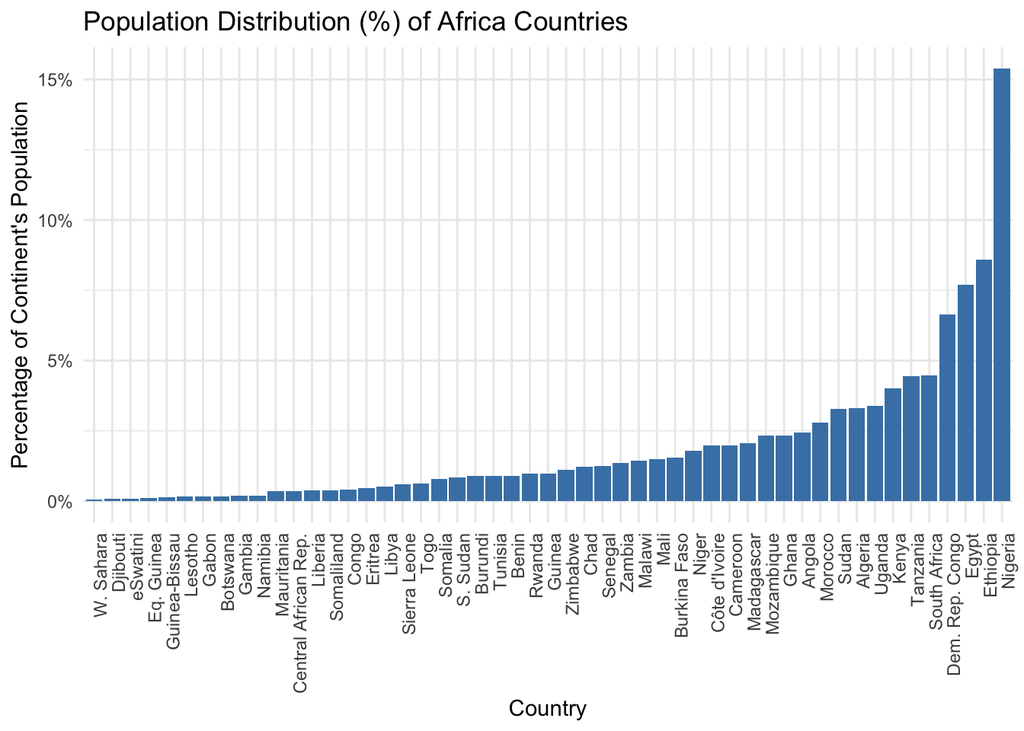

```r
print(plot_africa)
```

## 4 Locations

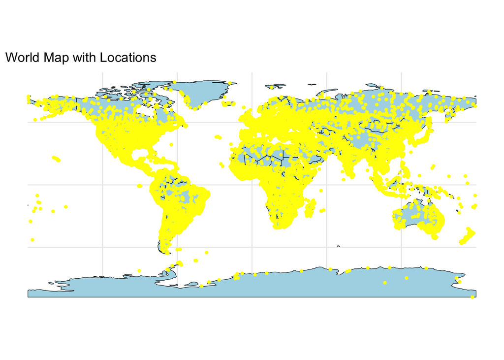

```r
#locations on map
ggplot() +
  # Plot world map
  geom_sf(data = countries, fill = "lightblue", color = "black") +
  # Plot airports on top
  geom_sf(data = locations, color = "yellow", size = 1) +
  theme_minimal() +
  labs(title = "World Map with Locations")
```

## 5 Average Distances’ Histogram (Airports)

```r
world <- ne_countries(scale = "medium", returnclass = "sf")
# Spatially join the population table with world to add country info
pop_with_country <- st_join(pop,
                            world[, c("sovereignt", "continent")],
                            join = st_intersects)

# Remove any rows that did not join to a country
pop_with_country <- pop_with_country %>%
  filter(!is.na(sovereignt))

# For each country, select the top 20 populated locations (using POP_MAX)
top20_pop <- pop_with_country %>%
  group_by(sovereignt) %>%                # Group by country name
  slice_max(order_by = POP_MAX,           # Order each group by the POP_MAX column
            n = 20,                     # Keep the top 20
            with_ties = FALSE) %>%       # Exclude ties beyond the 20th entry
  ungroup()
```

### 5.1 Airports

```r
#assign each airport a country
airports <- st_transform(airports, st_crs(world))
airports_with_country <- st_join(airports, world, join = st_intersects)

airports_with_country$sovereignt
```

[output not shown]

[output cut: 432 more lines]

```r
#check how many airports per country
airport_count_by_country <- airports_with_country %>%
  group_by(sovereignt) %>%
  summarise(airport_count = n())

print(airport_count_by_country)
```

```
## Simple feature collection with 171 features and 2 fields
## Geometry type: GEOMETRY
## Dimension:     XY
## Bounding box:  xmin: -175.1356 ymin: -53.78147 xmax: 179.1954 ymax: 78.24672
## Geodetic CRS:  WGS 84
## # A tibble: 171 × 3
##    sovereignt          airport_count                                    geometry
##    <chr>                       <int>                              <GEOMETRY [°]>
##  1 Afghanistan                     1                    POINT (69.21007 34.5634)
##  2 Albania                         1                   POINT (19.71503 41.42085)
##  3 Algeria                         3 MULTIPOINT ((-0.606797 35.62027), (3.21207…
##  4 Angola                          2 MULTIPOINT ((13.2348 -8.848313), (15.74976…
##  5 Antigua and Barbuda             1                  POINT (-61.79237 17.14036)
##  6 Argentina                      13 MULTIPOINT ((-65.09377 -24.3861), (-65.478…
##  7 Armenia                         1                   POINT (44.40006 40.15237)
##  8 Australia                      15 MULTIPOINT ((115.9742 -31.94113), (133.902…
##  9 Austria                         1                   POINT (16.56077 48.11976)
## 10 Azerbaijan                      1                   POINT (50.04984 40.46275)
## # ℹ 161 more rows
```

```r
airports_cleaned <- airports_with_country %>%
  filter(!is.na(sovereignt))
```

```r
# First, let's see what columns we have in airports_cleaned
print("Columns in airports_cleaned:")
```

```
## [1] "Columns in airports_cleaned:"
```

```r
names(airports_cleaned)
```

```
##   [1] "scalerank.x"  "featurecla.x" "type.x"       "name.x"       "abbrev.x"
##   [6] "location"     "gps_code"     "iata_code"    "wikipedia"    "natlscale"
##  [11] "comments"     "wikidataid.x" "name_ar.x"    "name_bn.x"    "name_de.x"
##  [16] "name_en.x"    "name_es.x"    "name_fr.x"    "name_el.x"    "name_hi.x"
##  [21] "name_hu.x"    "name_id.x"    "name_it.x"    "name_ja.x"    "name_ko.x"
##  [26] "name_nl.x"    "name_pl.x"    "name_pt.x"    "name_ru.x"    "name_sv.x"
##  [31] "name_tr.x"    "name_vi.x"    "name_zh.x"    "wdid_score"   "ne_id.x"
##  [36] "name_fa.x"    "name_he.x"    "name_uk.x"    "name_ur.x"    "name_zht.x"
##  [41] "featurecla.y" "scalerank.y"  "labelrank"    "sovereignt"   "sov_a3"
##  [46] "adm0_dif"     "level"        "type.y"       "tlc"          "admin"
##  [51] "adm0_a3"      "geou_dif"     "geounit"      "gu_a3"        "su_dif"
##  [56] "subunit"      "su_a3"        "brk_diff"     "name.y"       "name_long"
##  [61] "brk_a3"       "brk_name"     "brk_group"    "abbrev.y"     "postal"
##  [66] "formal_en"    "formal_fr"    "name_ciawf"   "note_adm0"    "note_brk"
##  [71] "name_sort"    "name_alt"     "mapcolor7"    "mapcolor8"    "mapcolor9"
```

[output cut: 27 more lines]

```r
# Now let's check step by step
pop_airport_pairs <- top20_pop %>%
  group_by(sovereignt) %>%
  mutate(matching_airports = list(airports_cleaned[airports_cleaned$sovereignt == first(sovereignt), ])) %>%
  unnest(matching_airports, names_repair = "unique_quiet", names_sep = "_airport")

# Check what columns we actually have
print("Columns in pop_airport_pairs:")
```

```
## [1] "Columns in pop_airport_pairs:"
```

```r
names(pop_airport_pairs)
```

[output not shown]

[output cut: 334 more lines]

```r
within_country_distances <- pop_airport_pairs %>%
  select(
    sovereignt,
    city = NAME,
    airport = matching_airports_airportname.x,
    geometry,
    geometry_airport = matching_airports_airportgeometry
  ) %>%
  rowwise() %>%  # Process each row individually
  mutate(
    distance_km = as.numeric(st_distance(geometry, geometry_airport))/1000
  ) %>%
  ungroup() %>%  # Remove rowwise grouping
  arrange(sovereignt, distance_km)
```

```r
country_avg_distances <- within_country_distances %>%
  group_by(sovereignt) %>%
  summarise(
    avg_distance_km = mean(distance_km)
  ) %>%
  arrange(avg_distance_km)

# Let's look at the results
print(country_avg_distances)
```

```
## Simple feature collection with 157 features and 2 fields
## Geometry type: GEOMETRY
## Dimension:     XY
## Bounding box:  xmin: -175.2206 ymin: -41.29207 xmax: 174.7772 ymax: 64.14346
## Geodetic CRS:  WGS 84
## # A tibble: 157 × 3
##    sovereignt            avg_distance_km             geometry
##    <chr>                           <dbl>          <POINT [°]>
##  1 Saint Kitts and Nevis            1.05 (-62.71701 17.30203)
##  2 Iceland                          1.38 (-21.93655 64.14346)
##  3 Chad                             2.23   (15.0472 12.11504)
##  4 Burkina Faso                     2.50  (-1.52667 12.37226)
##  5 Qatar                            3.28  (51.53297 25.28656)
##  6 Mozambique                       3.48 (32.58722 -25.95333)
##  7 Laos                             3.50     (102.6 17.96669)
##  8 Senegal                          3.51 (-17.47508 14.71778)
##  9 Vanuatu                          3.53 (168.3166 -17.73335)
## 10 Turkmenistan                     4.23   (58.3833 37.94999)
## # ℹ 147 more rows
```

```r
# Create continent-wise data
continent_distances <- country_avg_distances %>%
  left_join(
    pop_airport_pairs %>%
      st_drop_geometry() %>%  # Remove the geometry to make it a regular dataframe
      select(sovereignt, continent) %>%
      distinct(),
    by = "sovereignt"
  )

print(continent_distances)
```

```
## Simple feature collection with 157 features and 3 fields
## Geometry type: GEOMETRY
## Dimension:     XY
## Bounding box:  xmin: -175.2206 ymin: -41.29207 xmax: 174.7772 ymax: 64.14346
## Geodetic CRS:  WGS 84
## # A tibble: 157 × 4
##    sovereignt            avg_distance_km             geometry continent
##    <chr>                           <dbl>          <POINT [°]> <chr>
##  1 Saint Kitts and Nevis            1.05 (-62.71701 17.30203) North America
##  2 Iceland                          1.38 (-21.93655 64.14346) Europe
##  3 Chad                             2.23   (15.0472 12.11504) Africa
##  4 Burkina Faso                     2.50  (-1.52667 12.37226) Africa
##  5 Qatar                            3.28  (51.53297 25.28656) Asia
##  6 Mozambique                       3.48 (32.58722 -25.95333) Africa
##  7 Laos                             3.50     (102.6 17.96669) Asia
##  8 Senegal                          3.51 (-17.47508 14.71778) Africa
##  9 Vanuatu                          3.53 (168.3166 -17.73335) Oceania
## 10 Turkmenistan                     4.23   (58.3833 37.94999) Asia
## # ℹ 147 more rows
```

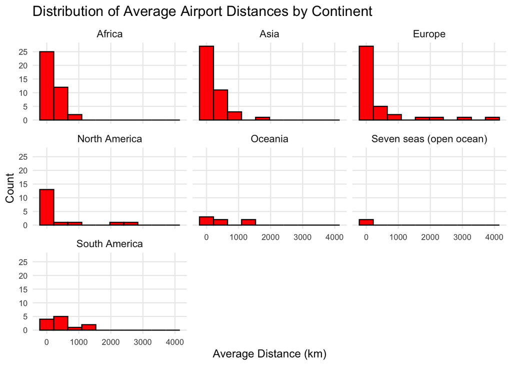

```r
ggplot(continent_distances, aes(x = avg_distance_km)) +
  geom_histogram(bins = 10, fill = "red", color = "black") +
  facet_wrap(~continent) +
  theme_minimal() +
  theme(
    axis.text.x = element_text(angle = 0, hjust = 0.5, size = 8),
    axis.text.y = element_text(size = 8),
    strip.text = element_text(size = 10),  # Continent labels size
    panel.grid.minor = element_blank(),
    plot.title = element_text(size = 14)   # Title size
  ) +
  scale_x_continuous(
    breaks = seq(0, 4000, by = 1000),
    labels = seq(0, 4000, by = 1000)
  ) +
  scale_y_continuous(
    breaks = seq(0, 25, by = 5)           # Set specific y-axis breaks
  ) +
  labs(
    x = "Average Distance (km)",
    y = "Count",
    title = "Distribution of Average Airport Distances by Continent"
  )
```

```r
## THE OUTLIERS IN THE HISTOGRAMS ARE PRESENT SINCE THERE ARE COUNTED THE TERRITORIES WHICH BELONG TO EUROPEAN COUNTRIES, FOR EXAMPLE QUEEN BEATRIZ INTERNATIONAL AIRPORT SO OUR FUNCTION CALCULATES DISTANCE BETWEEN AMSTERDAM AND DUTCH CARIBBEAN ISLAND OF ARUBA
```

## 6 Prepare data

```r
# Download and read the market coordinates data from a GitHub raw file
url <- "https://raw.githubusercontent.com/Viktoriag27/Geospatial_Assignment_2/main/Data/Part%202/MktCoords.xlsx"
temp_file <- tempfile(fileext = ".xlsx")
download.file(url, temp_file, mode = "wb")
market_data <- read_excel(temp_file)
```

```r
# Convert the market coordinates dataframe into a spatial sf object using longitude and latitude
market_sf <- st_as_sf(market_data, coords = c("longitude", "latitude"), crs = 4326)
print(market_sf)
```

```
## Simple feature collection with 230 features and 3 fields
## Geometry type: POINT
## Dimension:     XY
## Bounding box:  xmin: -17.36603 ymin: -29.3173 xmax: 49.18333 ymax: 19.61667
## Geodetic CRS:  WGS 84
## # A tibble: 230 × 4
##    ctrycode mktcode market                     geometry
##  * <chr>      <dbl> <chr>                   <POINT [°]>
##  1 AO           200 Luanda         (13.23444 -8.838333)
##  2 BJ           401 Cotonou         (2.433333 6.366667)
##  3 BJ           402 Malanville      (3.393031 11.86195)
##  4 BJ           403 Natitingou      (1.388616 10.31291)
##  5 BJ           404 Parakou             (2.616667 9.35)
##  6 BW           110 Gaborone       (25.90874 -24.65411)
##  7 BF           405 Bobo Dioulasso  (-4.291773 11.1781)
##  8 BF           406 Dedougou       (-3.463617 12.45462)
##  9 BF           407 Fada Ngourma    (0.360972 12.05481)
## 10 BF           408 Ouagadougou    (-1.533864 12.36464)
## # ℹ 220 more rows
```

```r
world_map <- map_data("world")
```

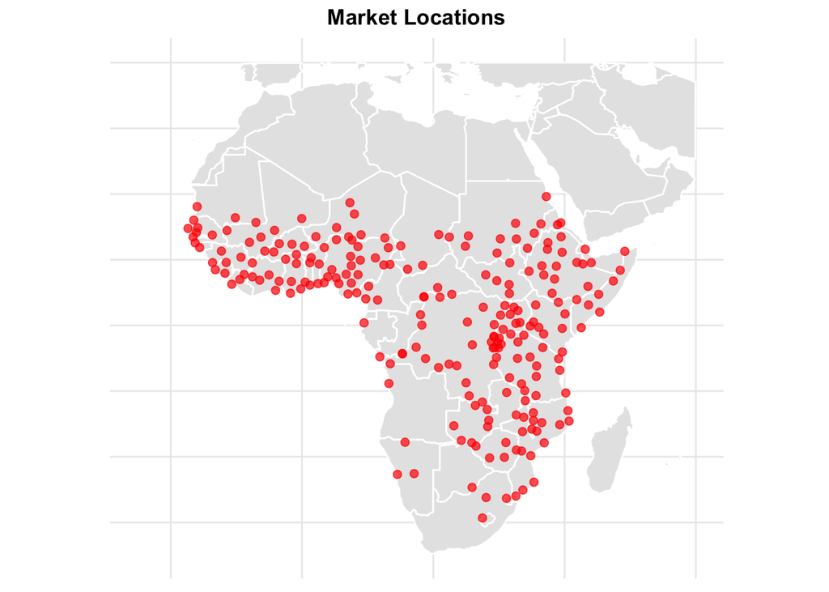

```r
# Filter for Africa’s
africa_map <- subset(world_map, long > -25 & long < 60 & lat > -40 & lat < 40)

# Create plot
ggplot() +
  geom_polygon(data = africa_map, aes(x = long, y = lat, group = group), fill = "gray90", color = "white") +
  geom_sf(data = market_sf, color = "red", size = 2, alpha = 0.7) +
  theme_minimal() +
  labs(title = "Market Locations") +  # Remove x and y labels
  theme(
    axis.title = element_blank(),  # Remove axis titles
    axis.text = element_blank(),   # Remove axis text
    axis.ticks = element_blank(),   # Remove axis ticks
    plot.title = element_text(hjust = 0.5, face = "bold")
  )
```

```r
# Download and read the price data from a GitHub raw file
price_file <- "https://raw.githubusercontent.com/Viktoriag27/Geospatial_Assignment_2/main/Data/Part%202/PriceMaster4GAMS.xlsx"
temp_file <- tempfile(fileext = ".xlsx")
download.file(price_file, temp_file, mode = "wb")
price_data <- read_excel(temp_file)

head(price_data)
```

```
## # A tibble: 6 × 148
##   mktcode country market  crop     `1`    `2`    `3`    `4`    `5`    `6`    `7`
##     <dbl> <chr>   <chr>   <chr>  <dbl>  <dbl>  <dbl>  <dbl>  <dbl>  <dbl>  <dbl>
## 1     200 Angola  Luanda  Maize NA     NA     NA     NA     NA     NA     NA
## 2     401 Benin   Cotonou Maize  0.250  0.250  0.263  0.277  0.299  0.300  0.311
## 3     401 Benin   Cotonou Rice   0.480  0.480  0.472  0.467  0.481  0.504  0.532
## 4     402 Benin   Malanv… Maize  0.169  0.176  0.189  0.203  0.216  0.205  0.266
## 5     402 Benin   Malanv… Sorg…  0.182  0.189  0.209  0.216  0.258  0.300  0.319
## 6     403 Benin   Natiti… Maize  0.189  0.216  0.216  0.243  0.258  0.270  0.311
## # ℹ 137 more variables: `8` <dbl>, `9` <dbl>, `10` <dbl>, `11` <dbl>,
## #   `12` <dbl>, `13` <dbl>, `14` <dbl>, `15` <dbl>, `16` <dbl>, `17` <dbl>,
## #   `18` <dbl>, `19` <dbl>, `20` <dbl>, `21` <dbl>, `22` <dbl>, `23` <dbl>,
## #   `24` <dbl>, `25` <dbl>, `26` <dbl>, `27` <dbl>, `28` <dbl>, `29` <dbl>,
## #   `30` <dbl>, `31` <dbl>, `32` <dbl>, `33` <dbl>, `34` <dbl>, `35` <dbl>,
## #   `36` <dbl>, `37` <dbl>, `38` <dbl>, `39` <dbl>, `40` <dbl>, `41` <dbl>,
## #   `42` <dbl>, `43` <dbl>, `44` <dbl>, `45` <dbl>, `46` <dbl>, `47` <dbl>, …
```

```r
# Convert price columns to numeric format, ignoring the first 4 columns
price_data <- price_data %>%
  mutate(across(5:ncol(.), as.numeric, .names = "num_{.col}"))
```

To calculate average market prices, we have taken the average price across all columns, assuming they represent different years, months, or days. Additionally, we compute the average price per market code (mktcode), without differentiating by crop type. This is because, for our analysis, we are interested in understanding market-level price trends rather than specific crop variations.

```r
# Compute the average price per market code by averaging across all price columns,
# assuming they represent different time periods (e.g., years, months, or days),
# without differentiating by crop type since it's not relevant for our analysis.
average_price <- price_data %>%
  rowwise() %>%
  mutate(avg_price = mean(c_across(5:ncol(.)), na.rm = TRUE)) %>%
  ungroup() %>%
  select(mktcode, avg_price) %>%
  group_by(mktcode) %>%
  summarise(avg_price = mean(avg_price, na.rm = TRUE))

# Print first few rows to verify the computed average prices
print(head(average_price))
```

```
## # A tibble: 6 × 2
##   mktcode avg_price
##     <dbl>     <dbl>
## 1     110     0.262
## 2     121     0.838
## 3     122     0.897
## 4     123     0.986
## 5     124     0.912
## 6     130     0.305
```

```r
# Merge market coordinates with the computed average prices
# using "mktcode" as the common key to link both datasets.
merged_data <- market_sf %>%
  left_join(average_price, by = "mktcode")

# Print the first few rows to verify that the merge was successful
print(head(merged_data))
```

```
## Simple feature collection with 6 features and 4 fields
## Geometry type: POINT
## Dimension:     XY
## Bounding box:  xmin: 1.388616 ymin: -24.65411 xmax: 25.90874 ymax: 11.86195
## Geodetic CRS:  WGS 84
## # A tibble: 6 × 5
##   ctrycode mktcode market                 geometry avg_price
##   <chr>      <dbl> <chr>               <POINT [°]>     <dbl>
## 1 AO           200 Luanda     (13.23444 -8.838333)     1.80
## 2 BJ           401 Cotonou     (2.433333 6.366667)     0.607
## 3 BJ           402 Malanville  (3.393031 11.86195)     0.257
## 4 BJ           403 Natitingou  (1.388616 10.31291)     0.459
## 5 BJ           404 Parakou         (2.616667 9.35)     0.311
## 6 BW           110 Gaborone   (25.90874 -24.65411)     0.262
```

## 7 Calculate Minimum Distances to Market Places

### 7.1 Coast line

```r
# Load coastline data from the Natural Earth dataset as an sf object
coastline <- ne_coastline(scale = "medium", returnclass = "sf")
```

```r
# Calculate minimum distance from market places to coastline
merged_data$dist_to_coast <- apply(st_distance(merged_data, coastline), 1, min)


# Convert distance from meters to kilometers
merged_data$dist_to_coast <- merged_data$dist_to_coast / 1000
```

### 7.2 Check the minimum distance calculated

```r
# Create graph to check if the minimum distance is correctly calculated

# Extract longitude and latitude from the geometry column of the sf object
merged_data <- merged_data %>%
  mutate(longitude = st_coordinates(.)[,1],
         latitude = st_coordinates(.)[,2])

# Filter the dataset to only include markets within Africa's bounding box
merged_data_africa <- merged_data %>%
  filter(longitude > -25 & longitude < 60 & latitude > -40 & latitude < 40)

# Filter Coastline for Africa Only
coastline_africa <- coastline %>%
  st_crop(xmin = -25, xmax = 60, ymin = -40, ymax = 40)

# Only include Africa
africa_map <- subset(world_map, long > -25 & long < 60 & lat > -40 & lat < 40)
```

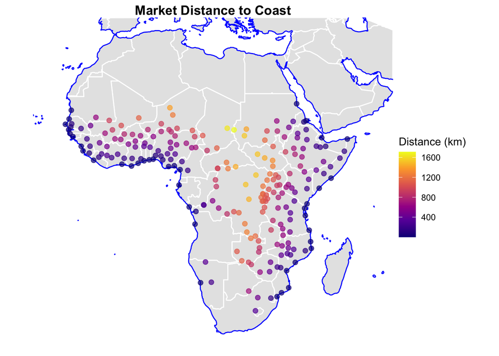

```r
# Create map
ggplot() +
  geom_polygon(data = africa_map, aes(x = long, y = lat, group = group),
               fill = "gray90", color = "white") +  # Africa background
  geom_sf(data = coastline_africa, color = "blue", size = 0.5) +  # Coastline in blue
  geom_sf(data = merged_data_africa, aes(color = dist_to_coast), size = 2, alpha = 0.7) +  # Market points
  scale_color_viridis_c(option = "plasma") +  # Better color scale
  coord_sf(xlim = c(-25, 60), ylim = c(-40, 40), expand = FALSE) +  # Restrict to Africa
  theme_void() +  # Removes grid lines and background
  labs(title = "Market Distance to Coast", color = "Distance (km)") +
  theme(plot.title = element_text(hjust = 0.5, face = "bold"))  # Center title
```

### 7.3 Create scatter plot that relates average prices with coastline

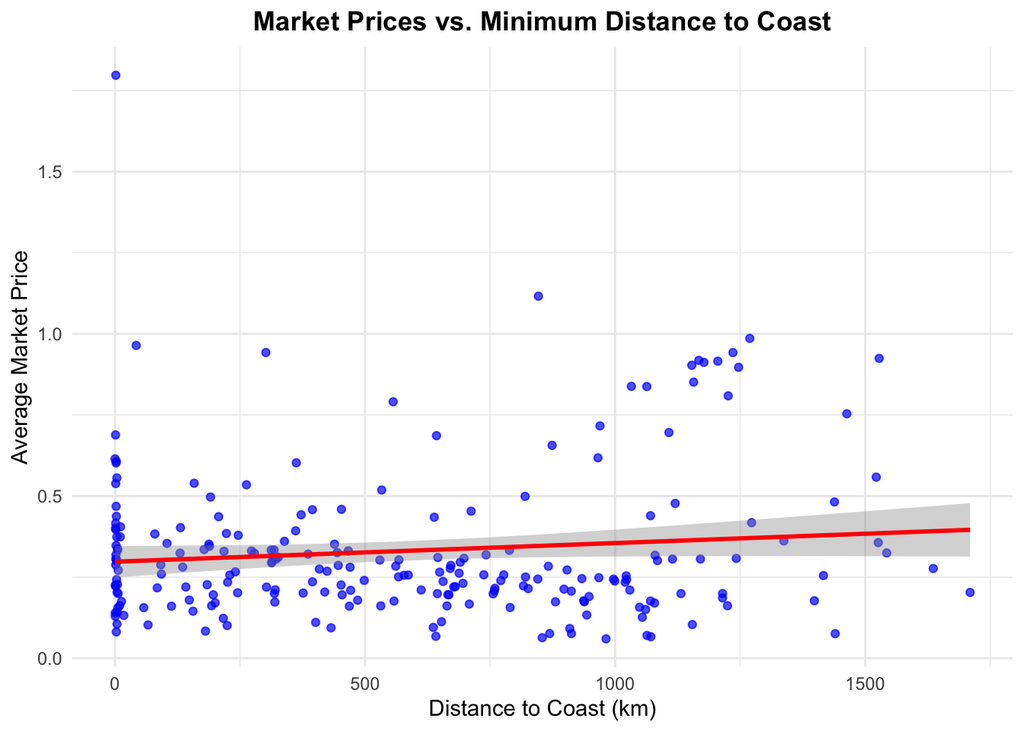

```r
# Create scatter plot that relates average prices with distance to coast line
ggplot(merged_data, aes(x = dist_to_coast, y = avg_price)) +
  geom_point(alpha = 0.7, color = "blue") +  # Scatter points
  geom_smooth(method = "lm", color = "red", se = TRUE) +  # Linear trend line
  theme_minimal() +
  labs(title = "Market Prices vs. Minimum Distance to Coast",
       x = "Distance to Coast (km)",
       y = "Average Market Price") +
  theme(plot.title = element_text(hjust = 0.5, face = "bold"))
```

The scatter plot does not reveal a clear pattern between market prices and distance to the coast. While the trend line suggests a slight positive relationship, the effect appears weak, with significant variation in prices at both short and long distances. The wide spread of data points and the broad confidence interval indicate that distance alone is not a strong predictor of market prices, suggesting that other factors, such as transportation infrastructure, local demand, or trade policies, may play a more significant role.

### 7.4 Roads

### 7.5 Calculate the minimum distance from markets to nearest roads

We now gather road data from Natural Earth. We filter on roads in Africa using the continent file and calculate the nearest road by first calculating the distance from each market to each road. Then we store the nearest roads with the shortest distances. We extract these roads and calculate the distance from market to nearest road in km. Finally we inspect our data to make sure the process ran smoothly.

```r
# Define the URL to the shapefile on GitHub
shp_url <- "/vsicurl/https://raw.githubusercontent.com/Viktoriag27/Geospatial_Assignment_2/main/Data/ne_10m_roads/ne_10m_roads.shp"
# Read the shapefile directly from the URL
road_data <- st_read(shp_url)
#Filter on raods in Africa
road_data<- road_data %>%
  filter(continent == "Africa")

# Calculate the distance between each market point and all road geometries
distances <- st_distance(merged_data, road_data)

# Identify the nearest road for each market
nearest_road_index <- apply(distances, 1, which.min)

# Extract the nearest road geometries
nearest_roads <- road_data[nearest_road_index, ]

# Add the nearest road geometry to the merged_data dataframe
merged_data$nearest_road_geom <- nearest_roads$geometry

# Calculate the distance to the nearest road in km
merged_data$distance_to_nearest_road <- as.numeric(apply(distances, 1, min)/1000)

# View our changes in merged_data
head(merged_data)
```

```
## Simple feature collection with 6 features and 8 fields
## Active geometry column: geometry
## Geometry type: POINT
## Dimension:     XY
## Bounding box:  xmin: 1.388616 ymin: -24.65411 xmax: 25.90874 ymax: 11.86195
## Geodetic CRS:  WGS 84
## # A tibble: 6 × 10
##   ctrycode mktcode market                 geometry avg_price dist_to_coast
##   <chr>      <dbl> <chr>               <POINT [°]>     <dbl>         <dbl>
## 1 AO           200 Luanda     (13.23444 -8.838333)     1.80           1.57
## 2 BJ           401 Cotonou     (2.433333 6.366667)     0.607          2.68
## 3 BJ           402 Malanville  (3.393031 11.86195)     0.257        586.
## 4 BJ           403 Natitingou  (1.388616 10.31291)     0.459        453.
## 5 BJ           404 Parakou         (2.616667 9.35)     0.311        327.
## 6 BW           110 Gaborone   (25.90874 -24.65411)     0.262        688.
## # ℹ 4 more variables: longitude <dbl>, latitude <dbl>,
## #   nearest_road_geom <MULTILINESTRING [°]>, distance_to_nearest_road <dbl>
```

For fun, we map the distance from markets to the nearest road.

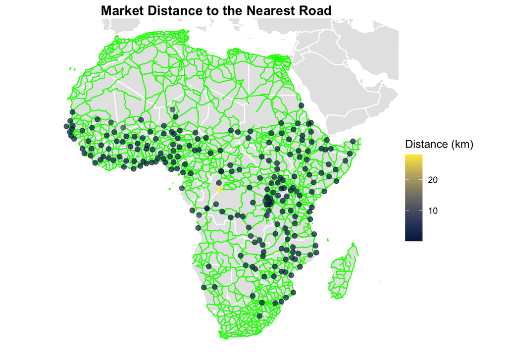

```r
# Create map
ggplot() +
  geom_polygon(data = africa_map, aes(x = long, y = lat, group = group),
               fill = "gray90", color = "white") +  # Africa background
  geom_sf(data = road_data, color = "green", size = 0.5) +
  geom_sf(data = merged_data, aes(color = distance_to_nearest_road), size = 2, alpha = 0.7) +  # Market points
  scale_color_viridis_c(option = "cividis") +  # Better color scale
  coord_sf(xlim = c(-25, 60), ylim = c(-40, 40), expand = FALSE) +  # Restrict to Africa
  theme_void() +  # Removes grid lines and background
  labs(title = "Market Distance to the Nearest Road", color = "Distance (km)") +
  theme(plot.title = element_text(hjust = 0.5, face = "bold"))  # Center title
```

### 7.6 Create scatter plot that relates average prices with nearest road

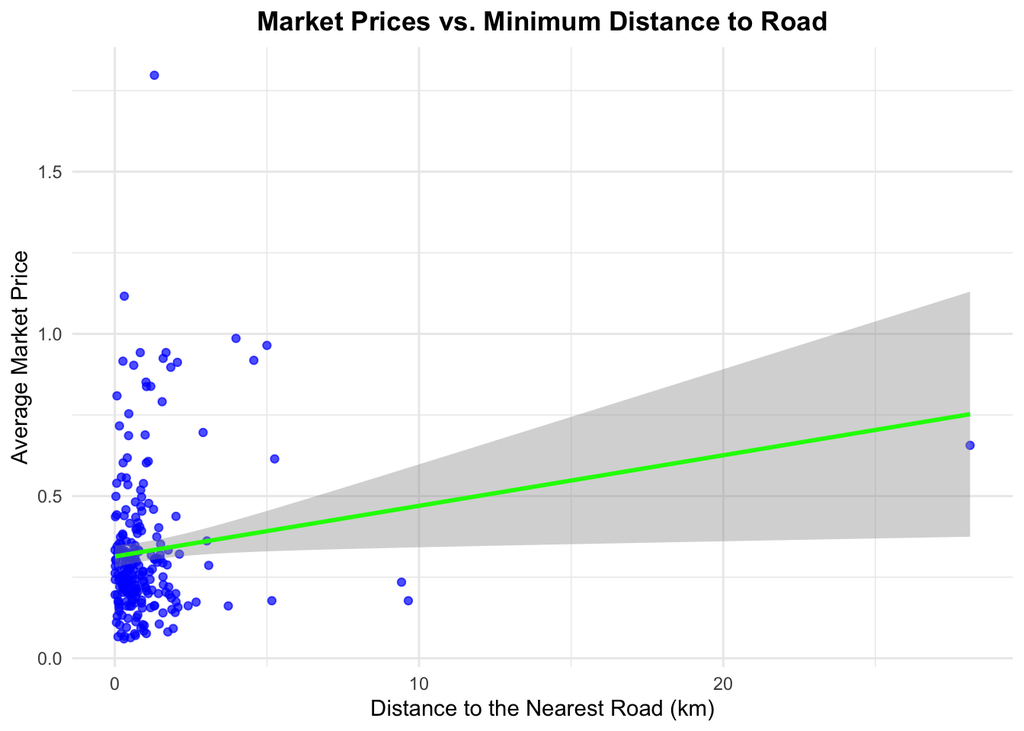

```r
# Create scatter plot that relates average prices with distance to nearest road
ggplot(merged_data, aes(x = distance_to_nearest_road, y = avg_price)) +
  geom_point(alpha = 0.7, color = "blue") +  # Scatter points
  geom_smooth(method = "lm", color = "green", se = TRUE) +  # Linear trend line
  theme_minimal() +
  labs(title = "Market Prices vs. Minimum Distance to Road",
       x = "Distance to the Nearest Road (km)",
       y = "Average Market Price") +
  theme(plot.title = element_text(hjust = 0.5, face = "bold"))
```

From this scatter plot, we detect no relationship between the average price of goods at the market and the distance to the nearest road. The trend line appears to have a positive slope but this is due to an outlier. Most markets are relatively close to roads and thus there are no identifiable trends in market pricing due to road access.

### 7.7 Airports

To gather data on airports in Africa, I used open source data from the afrimapr project and filtered on medium and large airports in Africa. I originally tried to use natural earth data; however, as there was no continent variable, I attempted to filter on airports in Africa by filtering on the bounding box. This created issues when I mapped my data as it also showed airports outside of Africa, such as on the Arabian Peninsula, that were within the bounding box. While it did not impact the distance calculation, it aesthetically did not look as organized or clear. I also tried to use st_within or st_intersect but encountered issues. Using the afrimapr data allowed for the simplest method and allowed me to map the markets and airports, which adds additional understanding to this project.

```r
# Load the dataset for African airports
data("afriairports")

# We select relevant columns, filter on large and medium airports, ensure the geometry is treated as points, and that the correct CRS is being used
africa_airports <- afriairports %>%
  select(name, country_name, geometry,type) %>%
  filter(type %in% c("large_airport", "medium_airport")) %>%
  st_as_sf() %>%  # Ensure it remains an sf object
  st_transform(crs = 4326)  # Optional: Set CRS to WGS84 (if needed)

# View the first few rows to ensure its correct
print(head(africa_airports))
```

```
## Simple feature collection with 6 features and 3 fields
## Geometry type: POINT
## Dimension:     XY
## Bounding box:  xmin: -8.0363 ymin: -33.9648 xmax: 36.9278 ymax: 33.3675
## Geodetic CRS:  WGS 84
## # A tibble: 6 × 4
##   name                              country_name           geometry type
##   <chr>                             <chr>               <POINT [°]> <chr>
## 1 OR Tambo International Airport    South Africa  (28.246 -26.1392) large_airpo…
## 2 Cairo International Airport       Egypt         (31.4056 30.1219) large_airpo…
## 3 Cape Town International Airport   South Africa (18.6017 -33.9648) large_airpo…
## 4 Jomo Kenyatta International Airp… Kenya        (36.9278 -1.31924) large_airpo…
## 5 Menara Airport                    Morocco       (-8.0363 31.6069) medium_airp…
## 6 Mohammed V International Airport  Morocco      (-7.58997 33.3675) large_airpo…
```

### 7.8 Calculate the minimum distance from markets to nearest airport

```r
# Calculate minimum distance from market places to airport
merged_data$dist_to_airport <- apply(st_distance(merged_data, africa_airports), 1, min)

# Convert distance from meters to kilometers
merged_data$dist_to_airport <- merged_data$dist_to_airport / 1000

# View the results of our calculation
print(head(merged_data))
```

```
## Simple feature collection with 6 features and 9 fields
## Active geometry column: geometry
## Geometry type: POINT
## Dimension:     XY
## Bounding box:  xmin: 1.388616 ymin: -24.65411 xmax: 25.90874 ymax: 11.86195
## Geodetic CRS:  WGS 84
## # A tibble: 6 × 11
##   ctrycode mktcode market                 geometry avg_price dist_to_coast
##   <chr>      <dbl> <chr>               <POINT [°]>     <dbl>         <dbl>
## 1 AO           200 Luanda     (13.23444 -8.838333)     1.80           1.57
## 2 BJ           401 Cotonou     (2.433333 6.366667)     0.607          2.68
## 3 BJ           402 Malanville  (3.393031 11.86195)     0.257        586.
## 4 BJ           403 Natitingou  (1.388616 10.31291)     0.459        453.
## 5 BJ           404 Parakou         (2.616667 9.35)     0.311        327.
## 6 BW           110 Gaborone   (25.90874 -24.65411)     0.262        688.
## # ℹ 5 more variables: longitude <dbl>, latitude <dbl>,
## #   nearest_road_geom <MULTILINESTRING [°]>, distance_to_nearest_road <dbl>,
## #   dist_to_airport <dbl>
```

We map the distance from markets to the nearest airport.

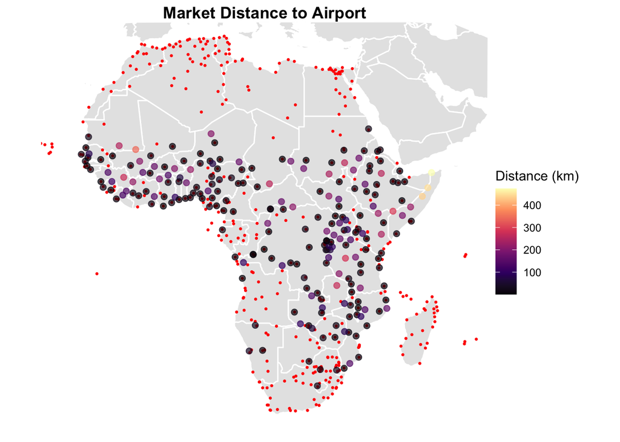

```r
library(ggplot2)
# Create map
ggplot() +
  geom_polygon(data = africa_map, aes(x = long, y = lat, group = group),
               fill = "gray90", color = "white") +  # Africa background
  geom_sf(data = africa_airports, color = "red", size = 0.5) +  # Airports in blue
  geom_sf(data = merged_data, aes(color = dist_to_airport), size = 2, alpha = 0.7) +  # Market points
  scale_color_viridis_c(option = "magma") +  # Better color scale
  coord_sf(xlim = c(-25, 60), ylim = c(-40, 40), expand = FALSE) +  # Restrict to Africa
  theme_void() +  # Removes grid lines and background
  labs(title = "Market Distance to Airport", color = "Distance (km)") +
  theme(plot.title = element_text(hjust = 0.5, face = "bold"))  # Center title
```

### 7.9 Create scatter plot that relates average prices with nearest airport

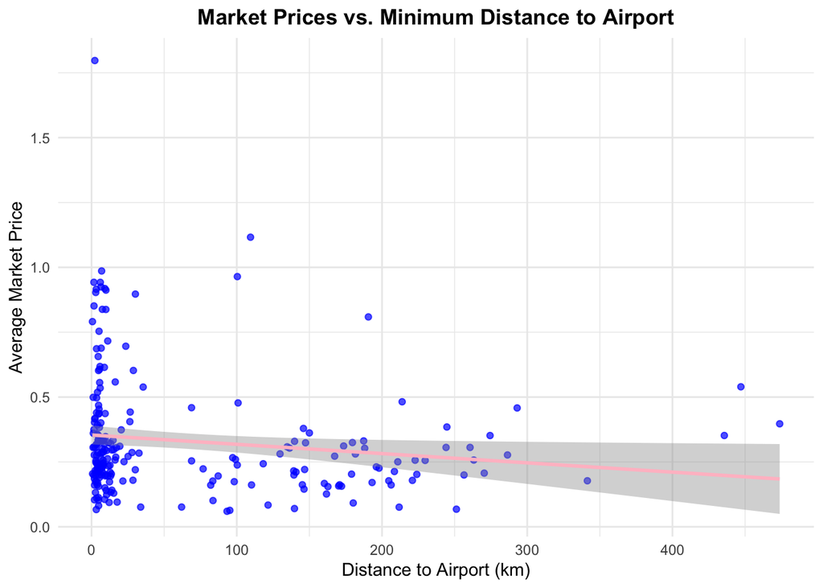

```r
# Create scatter plot that relates average prices with distance to airports
ggplot(merged_data, aes(x = dist_to_airport, y = avg_price)) +
  geom_point(alpha = 0.7, color = "blue") +  # Scatter points
  geom_smooth(method = "lm", color = "pink", se = TRUE) +  # Linear trend line
  theme_minimal() +
  labs(title = "Market Prices vs. Minimum Distance to Airport",
       x = "Distance to Airport (km)",
       y = "Average Market Price") +
  theme(plot.title = element_text(hjust = 0.5, face = "bold"))
```

Observing our results from the scatter plot, it is unclear if there is a relationship between the average price of goods at the market and the distance to the nearest airport. The trend line moves slightly downward, indicating a slight negative correlation as with price as distance increases. However, our data contains many higher and lower contradictory outliers.